# Better Know a Neurotoxin

Jeffrey A. Walker

04 March, 2022

# Learning Goals

1. Deep dive into a specific component of neuromuscular signaling
2. Fun with biological diversity
3. Making connections between human culture and biology and ecology
4. Literature search and Google Scholar skills
5. Reading the literature skills
6. Communicating science

# Background

Animal-derived neurotoxins are molecules synthesized by venomous or poisonous animals that bind to receptors on neurons or the skeletal muscle target cells of neurons and disrupt neuromuscular signaling. Physiologists have learned a lot about how neuron signaling works by controlled disruption of specific components of the system using some of these neurotoxins. You too can better know nervous system physiology by better knowing a neurotoxin.

## A summary of animal neurotoxins and their mechanism of action

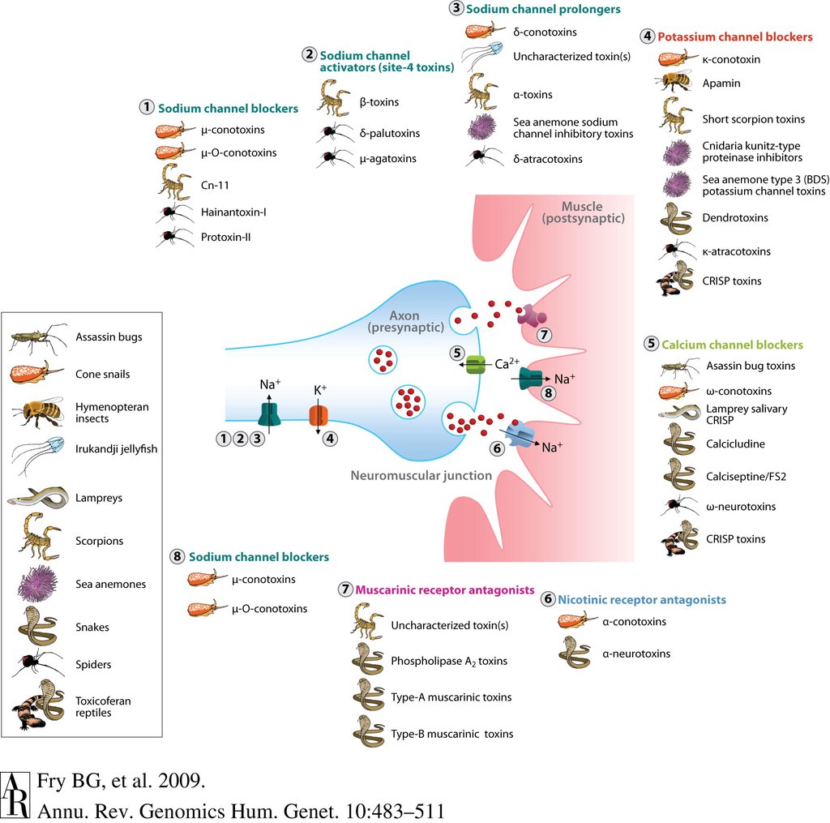

# The assignment

In this project, I want you to research how a neurotoxin of your choice works – this is called the **mechanism of action** – and summarize this research in a poster presentation using Google Slides. You won’t actually present the poster in person, but share the link with the class. You choose the neurotoxin, but to be relevant to the class, the mechanism of action must disrupt neuromuscular signaling. The poster will look something like this:

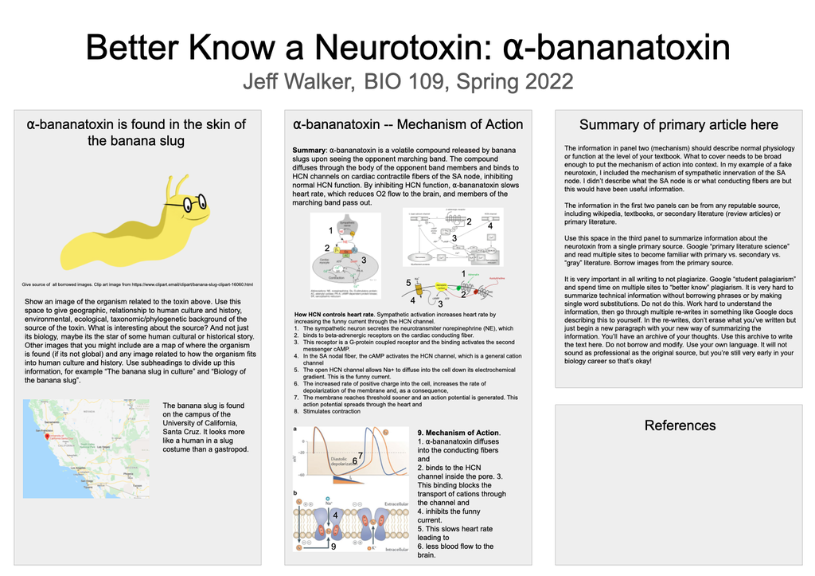

First, read the [Application in Neuroscience](https://en.wikipedia.org/wiki/Neurotoxin) section of the wikipedia article on neurotoxins.

Second, choose a neurotoxin to study from the image above. Some of these are in the list in the [Mechanisms of Activity](https://en.wikipedia.org/wiki/Neurotoxin#Mechanisms_of_activity) section of the wikipedia neurotoxin article.

Third, search wikipedia for the neurotoxin and read the article. If there is no wikipedia entry, choose another toxin. You want an article that describes in some way how the toxin disrupts the nervous system. This is the mechanism of action (or mechanism of activity or toxicodynamics). The figure above is the summary of the mechanism of action but it would be good to have more detail.

Your Poster should contain five sections

1. Title section including poster Title, student and class information
2. Organism section including 1) ecology and geography and other interesting bits of biology of the organism that synthesizes the neurotoxin, and 2) fun information on how humans use the toxin, if relevant
3. Mechanism of Action section including 1) a summary mechanism of action, 2) a step by step, numbered list of normal signaling relevant to the neurotoxin, and 3) A step by step, numbered list of the mechanism of action, with reference to the normal signaling list (“this blocks step 3”).
4. Primary article section. Use [Google scholar](https://scholar.google.com) to find a **primary research article** about your neurotoxin. You want to present recent discoveries so **the research article must be published since 2010**. Download the article. Scan the sections and figures of the article. Choose one figure in the article to describe. The figure should be a primary result, such as 1) the result of an experiment, of 2) the result of a an analysis of the neurotoxin structure or structure of a neuromuscular protein that it binds to, or a result of the relationship between different versions of the neurotoxin. This section should include the figure and your summary of the experiment/analysis that created the data for the figure and summary of the implications. This will be hard to do. Struggle some. Don’t plagiarize as a crutch. The goal is for you to practice this.
5. References (cite all sources, including the web address of the images)

# Quick tutorials on skills needed for this Better Know

## The basics of a literature search

There are two basic ways of searching the literature:

**Keyword search** – If I want to search for the latest publications related to the hormones secreted by skin cells I might start with the key words “skin”, “hormone”, “endocrine”. I could also google the name of the skin cell type and add this to the search. The difficulty is finding papers that report on hormones secreted by skin cells and not papers that report on skin cells as the target of hormones.

**Citation search** – A super effective method for literature searching is a citation search. Typically a keyword search will yield a few seminal papers that influenced a field. You can get a sense of the influence by the number of citations to the paper. In a citation search, you find relevant papers to your goals by looking at the papers that cite these early, influential papers (see below for how to do this with Google Scholar).

**Strategy**

Searching the literature (“building a bibliography”) is a skill – the more you do it the better you get because you will become more efficient (finding more relevant publications in less time). You become more efficient because you begin to identify strategies that work and strategies that don’t.

If I want to search for the latest publications related to the hormones secreted by skin cells

1. I might start with Google Scholar using the key words “skin”, “hormone”, “endocrine” and then look at the results. If the results return relevant papers then good! If not, then…
2. I might go to a Google search (and not Google Scholar), and use a search like (including the quotes) “hormones secreted by skin cells” or variations of this phrase. This would hopefully return web sites with the names of one or more hormones that I could specifically search in Google Scholar.
3. I might add to either the initial Google Scholar search or the Google search the names of specific skin cell types like “keritinocyte”. If I don’t know the names of the cell types, I would find these using a Google search. This includes the cell types of the various glands in the dermis of the skin.
4. A goal with any search is to avoid outdated information so we want to focus on more recent papers. Older publications are useful for finding newer publications using the citation search method.
5. A goal with any search is to focus on publications that are likely to be more reliable. The number of citations to a paper is an imperfect measure of reliability. But age of the paper (how long ago the paper was published) matters as older papers have had more time to accumulate citations.

## Primary vs. Secondary research articles

The **Primary** literature (or primary sources) consists of articles published in scientific journals (not books!) that report original research. For this class, this will generally be experiments on mice, but sometimes humans.

How to recognize an article is a primary research paper

- [The abstract describes experimental results](https://jasn.asnjournals.org/content/28/5/1507?utm_source=TrendMD&utm_medium=cpc&utm_campaign=J_Am_Soc_Nephrol_TrendMD_0&WT.MC_ID=TMD0)
- [In some journals, the article includes a header stating that it is a “research article” or something similar](https://science.sciencemag.org/content/360/6390/758)

The **Secondary** literature consists of articles published in scientific journals or edited books that **review** and synthesize previously published research.

How to recognize secondary literature?

- [Often the journal has a header that says “Review” or something like that](https://www.karger.com/Article/Abstract/479968).
- [The authors state explicitly that the article is a review](https://www.sciencedirect.com/science/article/pii/S0303720721001039).

## How to find the Chicago style quote in Google scholar

Look at the bottom line of the entry, which starts with a star. The big quotes to the right of the star is a link to different styles of citing the article. You will use this for this assignment. Click on this and you get a pop-up window with the different styles. Click on the Chicago style and the whole citation highlights. Copy this to the clipboard and paste in your report.

## How to use an article in Google scholar to find more recent articles that cite it

To narrow down the list to potential review (secondary sources) papers:

- click the “search within citing articles” box
- type “review” in the search field
- click the search icon
- type “review”

## How to get a PDF of the article

1. For many articles, a link to the PDF is to the right of the google scholar entry.
2. Sometimes, a pdf link is not to the right (it says “HTML”) but is within the **All xxx versions** link in the last line of the entry.
3. Some journals provide free access to the article. If the above don’t work, click the link to the journal website.
4. NIH/Pubmed often provides a version of the published paper. After clicking on the **All xxx versions** link, you should see a link that looks like image below. In the green text beneath the article title, you see **ncbi.nlm.nih.gov** and to the right you see **[HTML] nih.gov**. Click this entry to go to the pubmed version of the article. You might find a “full text” or “pdf” link from this page
5. E-mail the communicating author!

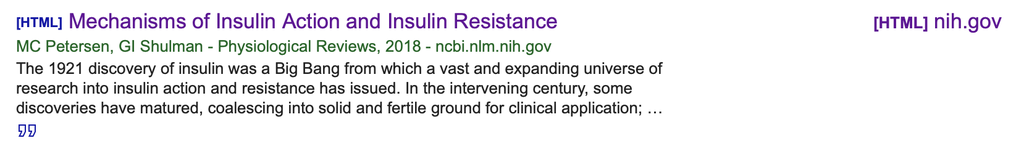